# TP 1 : Distances & Introduction à la CAH

M1 MAS

2026-02-03

## Exercice 1 : Données quantitatives

Importation et Distances

**Question 1 :** La fonction `dist` de base dans R permet de calculer plusieurs types de distances : *euclidean, maximum, manhattan, canberra, binary, et minkowski*.

**Question 2 :** Importation et calcul de la distance euclidienne.

```r
# Importation (Source: 4)
df_produits <- read.delim("Product_appreciation.txt", header=TRUE, row.names=1, sep = ",")
print(df_produits)
```

```
##       C1   C2
## P1   8.0  8.5
## P2  12.0 11.0
## P3  15.5 18.0
## P4  14.0 16.0
## P5  10.0  9.0
## P6  10.0 12.0
## P7   5.0  6.5
## P8   9.0  9.0
## P9  18.5 20.0
## P10 13.0 16.0
```

```r
# Calcul de la matrice de distance (Euclidienne par défaut)
dist_mat_euc <- dist(df_produits, method = "euclidean")

print(round(dist_mat_euc, 2))
```

```
##        P1    P2    P3    P4    P5    P6    P7    P8    P9
## P2   4.72
## P3  12.10  7.83
## P4   9.60  5.39  2.50
## P5   2.06  2.83 10.55  8.06
## P6   4.03  2.24  8.14  5.66  3.00
## P7   3.61  8.32 15.57 13.09  5.59  7.43
## P8   1.12  3.61 11.10  8.60  1.00  3.16  4.72
## P9  15.57 11.10  3.61  6.02 13.90 11.67 19.09 14.53
## P10  9.01  5.10  3.20  1.00  7.62  5.00 12.42  8.06  6.80
```

### Analyse des résultats

**Question 3 :** Quels produits sont les plus proches ?

```r
mat_euc <- as.matrix(dist_mat_euc)
# On remplace la diagonale (0) par Inf pour trouver le vrai minimum
diag(mat_euc) <- Inf
min_val <- min(mat_euc)
indices <- which(mat_euc == min_val, arr.ind = TRUE)

p1 <- rownames(mat_euc)[indices[1,1]]
p2 <- rownames(mat_euc)[indices[1,2]]

cat("La distance minimale est de", min_val, "\n")
```

```
## La distance minimale est de 1
```

```r
cat("Les produits les plus proches sont :", p1, "et", p2, "\n")
```

```
## Les produits les plus proches sont : P10 et P4
```

## Exercice 2 : Données qualitatives

Transformation des données

**Question 1 :** Transformation en tableau disjonctif complet.

```r
df_medical <- read.table("Fictive_medical_data.txt", header=TRUE, row.names=1, sep = ",")

# Utilisation de FactoMineR (Source: 16)
# Note: tab.disjonctif ne fonctionne que sur les facteurs, on s'assure de la conversion
for(i in 1:ncol(df_medical)) df_medical[,i] <- as.factor(df_medical[,i])

tab_disj <- tab.disjonctif(df_medical)
print(tab_disj)
```

```
##         F H Fievre.N P Toux.N P Test1.N P Test2.N P Test3.N P Test4.N P
## Chloe   1 0        0 1      0 1       1 0       1 0       1 0       1 0
## Florian 0 1        0 1      0 1       0 1       0 1       1 0       0 1
## Marie   1 0        1 0      1 0       0 1       1 0       0 1       0 1
## Margaux 1 0        0 1      1 0       0 1       1 0       0 1       1 0
## Antonin 0 1        1 0      1 0       0 1       0 1       0 1       1 0
## Celine  1 0        0 1      0 1       0 1       1 0       1 0       1 0
```

Programmation des distances

Formules de dissimilarité :

- **Sokal & Michener** : (Mismatches) / Total
- **Jaccard** : (Mismatches 1-0 ou 0-1) / (Total - Matches 0-0)

```r
# Fonctions
dist_sokal_michener <- function(x, y) {
  # Dissimilarité = nombre de différences / nombre total de variables
  return(sum(x != y) / length(x))
}

dist_jaccard <- function(x, y) {
  # a = 1-1, b = 1-0, c = 0-1
  # Jaccard dissimilarity = (b + c) / (a + b + c)
  # Donc on ignore les cas 0-0
  b_plus_c <- sum(x != y) # Différents
  a <- sum(x == 1 & y == 1) # 1 et 1

  if((a + b_plus_c) == 0) return(0) # Protection div par 0
  return(b_plus_c / (a + b_plus_c))
}

# Test sur l'exemple du sujet
xi <- c(1,0,0,0,1,1)
xj <- c(1,0,0,1,0,0)

cat("Test Sokal & Michener :", dist_sokal_michener(xi, xj), "\n")
```

```
## Test Sokal & Michener : 0.5
```

```r
cat("Test Jaccard :", dist_jaccard(xi, xj), "\n")
```

```
## Test Jaccard : 0.75
```

Matrices de dissimilarités et Analyse

**Questions 4 & 5 :** Calcul sur les données médicales.

```r
# Le tableau disjonctif est déjà binaire (0/1)
data_bin <- as.matrix(tab_disj)
n <- nrow(data_bin)
mat_sokal <- matrix(0, n, n, dimnames = list(rownames(data_bin), rownames(data_bin)))
mat_jaccard <- matrix(0, n, n, dimnames = list(rownames(data_bin), rownames(data_bin)))

for (i in 1:n) {
  for (j in 1:n) {
    mat_sokal[i, j] <- dist_sokal_michener(data_bin[i, ], data_bin[j, ])
    mat_jaccard[i, j] <- dist_jaccard(data_bin[i, ], data_bin[j, ])
  }
}

print("Matrice Sokal & Michener (extrait):")
```

```
## [1] "Matrice Sokal & Michener (extrait):"
```

```r
print(round(mat_sokal, 3))
```

```
##         Chloe Florian Marie Margaux Antonin Celine
## Chloe   0.000   0.571 0.714   0.429   0.857  0.143
## Florian 0.571   0.000 0.714   0.714   0.571  0.429
## Marie   0.714   0.714 0.000   0.286   0.429  0.571
## Margaux 0.429   0.714 0.286   0.000   0.429  0.286
## Antonin 0.857   0.571 0.429   0.429   0.000  0.714
## Celine  0.143   0.429 0.571   0.286   0.714  0.000
```

```r
print("Matrice Jaccard (extrait):")
```

```
## [1] "Matrice Jaccard (extrait):"
```

```r
print(round(mat_jaccard, 3))
```

```
##         Chloe Florian Marie Margaux Antonin Celine
## Chloe   0.000   0.727 0.833   0.600   0.923  0.250
## Florian 0.727   0.000 0.833   0.833   0.727  0.600
## Marie   0.833   0.833 0.000   0.444   0.600  0.727
## Margaux 0.600   0.833 0.444   0.000   0.600  0.444
## Antonin 0.923   0.727 0.600   0.600   0.000  0.833
## Celine  0.250   0.600 0.727   0.444   0.833  0.000
```

```r
# Individus les plus proches (Sokal)
diag(mat_sokal) <- Inf
min_s <- min(mat_sokal)
inds_s <- which(mat_sokal == min_s, arr.ind=TRUE)[1,]
cat("\nPlus proches (Sokal) :", rownames(mat_sokal)[inds_s[1]], "et", rownames(mat_sokal)[inds_s[2]], "( d =", min_s,")\n")
```

```
##
## Plus proches (Sokal) : Celine et Chloe ( d = 0.1428571 )
```

```r
# Individus les plus proches (Jaccard)
diag(mat_jaccard) <- Inf
min_j <- min(mat_jaccard)
inds_j <- which(mat_jaccard == min_j, arr.ind=TRUE)[1,]
cat("Plus proches (Jaccard) :", rownames(mat_jaccard)[inds_j[1]], "et", rownames(mat_jaccard)[inds_j[2]], "( d =", min_j,")\n")
```

```
## Plus proches (Jaccard) : Celine et Chloe ( d = 0.25 )
```

## Exercice Facultatif : Distance du Khi-2

**Questions 1 & 2 :** Programmation et test sur Chloé et Margaux.

```r
# Fonction distance du Chi2 entre deux profils lignes i et j
dist_chi2_manual <- function(row_i, row_j, data_matrix) {
  # Somme totale du tableau
  N <- sum(data_matrix)
  # Marges colonnes (p_k)
  col_sums <- colSums(data_matrix)
  p_k <- col_sums / N

  # Profils lignes (divisés par leur somme ligne respective)
  prof_i <- row_i / sum(row_i)
  prof_j <- row_j / sum(row_j)

  # Formule distance chi2 pondérée par l'inverse des marges colonnes
  # d²(i,j) = sum [ (1/p_k) * (prof_i_k - prof_j_k)^2 ]
  d2 <- sum( (1/p_k) * (prof_i - prof_j)^2 )
  return(sqrt(d2))
}

# Application à Chloé et Margaux (Exercice 2)
# Chloé est la ligne 1, Margaux est la ligne 4

data_bin
```

```
##         F H Fievre.N P Toux.N P Test1.N P Test2.N P Test3.N P Test4.N P
## Chloe   1 0        0 1      0 1       1 0       1 0       1 0       1 0
## Florian 0 1        0 1      0 1       0 1       0 1       1 0       0 1
## Marie   1 0        1 0      1 0       0 1       1 0       0 1       0 1
## Margaux 1 0        0 1      1 0       0 1       1 0       0 1       1 0
## Antonin 0 1        1 0      1 0       0 1       0 1       0 1       1 0
## Celine  1 0        0 1      0 1       0 1       1 0       1 0       1 0
```

```r
row_chloe <- data_bin["Chloe", ]
row_margaux <- data_bin["Margaux", ]

d_chi2 <- dist_chi2_manual(row_chloe, row_margaux, data_bin)
cat("Distance du Chi2 entre Chloé et Margaux :", round(d_chi2, 4))
```

```
## Distance du Chi2 entre Chloé et Margaux : 1.4736
```

## Exercice 3 : CAH

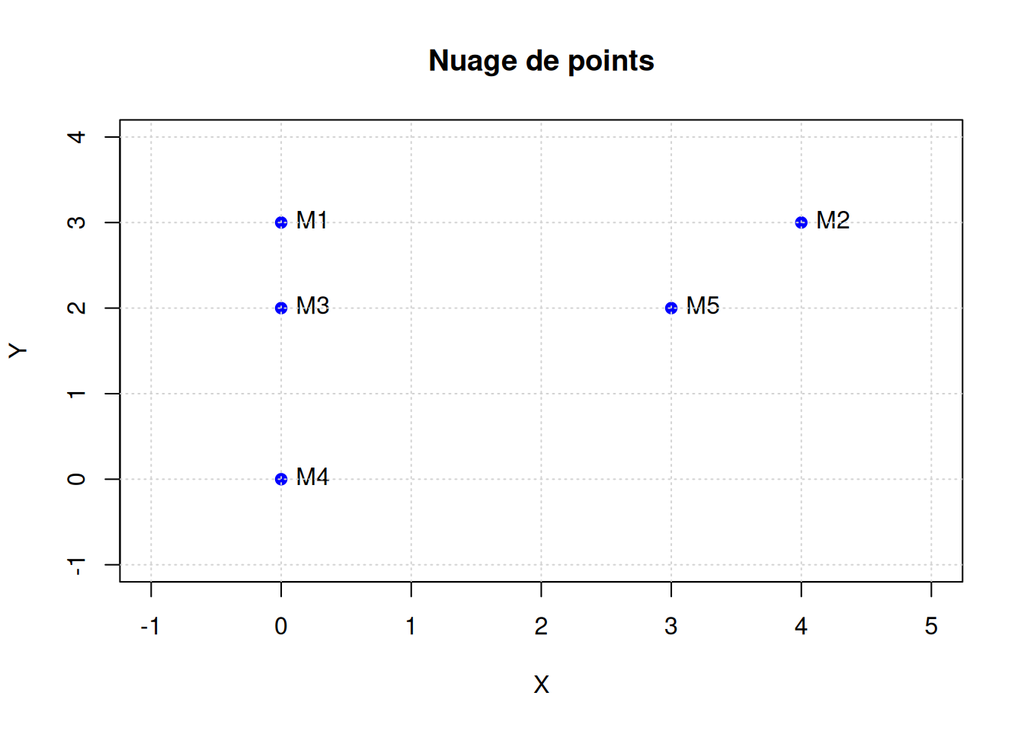

```r
# Définition des points M1 à M5
df_points <- data.frame(
  x = c(0, 4, 0, 0, 3),
  y = c(3, 3, 2, 0, 2)
)
rownames(df_points) <- c("M1", "M2", "M3", "M4", "M5")

# 1. Nuage de points
plot(df_points$x, df_points$y, pch=19, col="blue",
     xlim=c(-1,5), ylim=c(-1,4), xlab="X", ylab="Y",
     main="Nuage de points")
text(df_points$x, df_points$y, labels=rownames(df_points), pos=4)
grid()
```

**Question 3 :** Matrice de distance euclidienne au carré.

```r
# Distance euclidienne
d_euc <- dist(df_points, method="euclidean")
# Au carré
d_sq <- d_euc^2
print("Matrice des distances au carré :")
```

```
## [1] "Matrice des distances au carré :"
```

```r
print(d_sq)
```

```
##    M1 M2 M3 M4
## M2 16
## M3  1 17
## M4  9 25  4
## M5 10  2  9 13
```